# Chapter 18 Coding Homework

Pablo Bello

```r
###--- Libraries
library(tidyverse)
library(lubridate)
library(hrbrthemes)
library(fixest)
library(broom)
library(janitor)

theme_set(theme_ipsum())
```

Follow the below instructions and turn in both your code and results:

1. In this assignment we will be walking through a very simple application of difference-in-differences that comes from Peter Nencka. In particular, it seemed that the beginning of the COVID-19 pandemic led to a brief craze for homemade sourdough bread, as people had to stay home, and stores were out of yeast (sourdough can be made at home using yeast from the air and does not require store-bought yeast). We will be estimating whether COVID lockdowns actually increased interest in sourdough bread,

We will be measuring interest in sourdough bread using Google Trends data in the USA. Google Trends tracks the popularity of different search terms over time. We will be comparing the popularity of the search term “sourdough” against the control groups: the search terms “cereal,” “soup,” and “sandwich,” the popularity of which we suspect might not have been meaningfully affected by COVID lockdowns.

Load the data set `sourdough_trends.csv` and look through the data. In R or Python, save the dataset as `sr`.

Then, limit the data to just the variables of interest: `date`, `hits` (the Google Trends index), and `keyword`, the search term we’re examining.

Finally, convert the “date” variable to a usable date.

```r
###--- Load the data
tbl <- read_delim("week_11/sourdough.txt", delim = ",")

tbl <-
  tbl |>
  select(date,hits,keyword) |>
  mutate(date = ymd(date))

###--- Treatment date
t_date <- as.Date("2020-03-15")
```

2. Make a line graph with `date` on the x-axis and `hits` on the y-axis, with a separate line for each `keyword`. Also add a vertical line for the “start of the pandemic” which we’ll decide for our purposes is March 15, 2020.

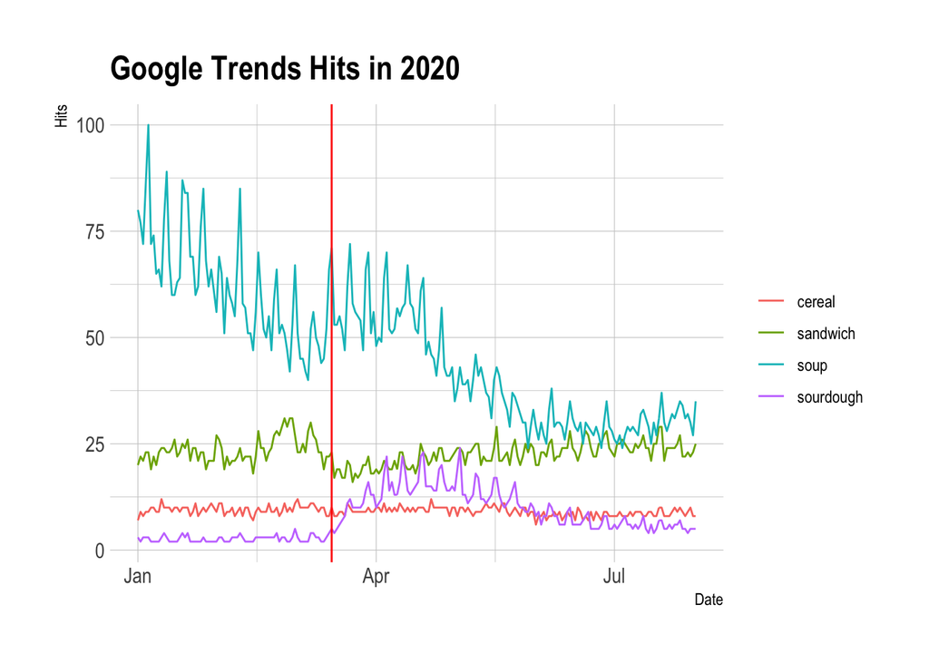

```r
###--- Plot
tbl |>
  ggplot(aes(date,hits, color = keyword)) +
  geom_line() +
  geom_vline(aes(xintercept = t_date), color = "red") +
  labs(title = "Google Trends Hits in 2020",
       x = "Date",
       y = "Hits",
       color = "")
```

3. Looking at your graph from problem 2, comment on (a) whether it looks like the lockdown had an effect on the popularity of sourdough, (b) the shape that effect takes (i.e. is it a permanent increase in popularity? Temporary?), (c) whether you might be concerned about any of the control groups we’ve chosen

**Sandwich and cereal have rather stable trends so they are good controls. However, soup does not. It seems that people are more into soup in the winter than in summer, Americans have not discovered Gazpacho yet. In other words, because the trend has a strong seasonal component it is not a good control for sourdough.**

4. Create a “Treated” indicator that’s equal to 1 for sourdough and 0 otherwise (or True/False, either way). Do a test of whether the prior trends (keeping March 15 as the “treatment date”) differ between the treated and control groups, using a linear trend and doing a statistical significance test at the 95% level. Then, if you were concerned about any of the control groups in question 3c, drop any you were concerned about (and keep them dropped for the rest of the assignment) and rerun the test.

Write a line commenting on whether you can reject equal prior trends in your model(s).

```r
###---
tbl2 <-
  tbl |>
  mutate(treated = if_else(keyword == "sourdough", TRUE, FALSE),
         treated_period = if_else(date >= t_date, TRUE,FALSE)) |>
  filter(treated_period == FALSE)


###---
m1 <- lm(hits ~  date*treated,
         data =  tbl2)

summary(m1)
```

```
##
## Call:
## lm(formula = hits ~ date * treated, data = tbl2)
##
## Residuals:
##     Min      1Q  Median      3Q     Max
## -29.312 -16.569  -0.780   4.653  64.198
##
## Coefficients:
##                    Estimate Std. Error t value Pr(>|t|)
## (Intercept)       2.365e+03  1.166e+03   2.028   0.0435 *
## date             -1.275e-01  6.374e-02  -2.001   0.0464 *
## treatedTRUE      -2.476e+03  2.333e+03  -1.061   0.2894
## date:treatedTRUE  1.337e-01  1.275e-01   1.049   0.2950
## ---
## Signif. codes:  0 '***' 0.001 '**' 0.01 '*' 0.05 '.' 0.1 ' ' 1
##
## Residual standard error: 20.29 on 292 degrees of freedom
## Multiple R-squared:  0.2868, Adjusted R-squared:  0.2794
## F-statistic: 39.13 on 3 and 292 DF,  p-value: < 2.2e-16
```

```r
###--- Drop Soup
tbl2 <-
  tbl2 |>
  filter(keyword != "soup")

###---
m2 <- lm(hits ~  date*treated,
         data =  tbl2)

summary(m2)
```

```
##
## Call:
## lm(formula = hits ~ date * treated, data = tbl2)
##
## Residuals:
##     Min      1Q  Median      3Q     Max
## -9.7646 -6.1886  0.1393  4.9091 13.8877
##
## Coefficients:
##                    Estimate Std. Error t value Pr(>|t|)
## (Intercept)      -513.64175  428.58090  -1.198    0.232
## date                0.02897    0.02342   1.237    0.217
## treatedTRUE       402.75972  742.32390   0.543    0.588
## date:treatedTRUE   -0.02277    0.04057  -0.561    0.575
##
## Residual standard error: 6.086 on 218 degrees of freedom
## Multiple R-squared:  0.5423, Adjusted R-squared:  0.536
## F-statistic: 86.11 on 3 and 218 DF,  p-value: < 2.2e-16
```

**Equal prior trends hold in both cases as the interaction terms is likely 0, meaning that the time coefficients for treatment and controls are not very different.**

5. Create a `month` variable by shifting the `date` variable back 15 days (so that the treatment day is the first day of the month) and then taking the month of the resulting date. Also create an `After` variable equal to 1/0 (or True/False) if the date is March 15 or afterwards.

**That approach to take the month out is gonna send the 1-14 of January to December, no bueno.**

```r
###--- Wrangle the date into a numeric centered on 0 (treatment date)
tbl3 <-
  tbl |>
  filter(keyword != "soup") |>
  mutate(month = ceiling(as.numeric(date - (t_date - 1))/30),
         month2 = month(date),
         after = if_else(date >= t_date, TRUE, FALSE),
         treated = if_else(keyword == "sourdough", TRUE, FALSE),
         treated_inter = if_else(after == TRUE & treated == TRUE,TRUE,FALSE))


###--- Check
tbl3 |>
    count(after, month, month2)
```

```
## # A tibble: 15 × 4
##    after month month2     n
##    <lgl> <dbl>  <dbl> <int>
##  1 FALSE    -2      1    42
##  2 FALSE    -1      1    51
##  3 FALSE    -1      2    39
##  4 FALSE     0      2    48
##  5 FALSE     0      3    42
##  6 TRUE      1      3    51
##  7 TRUE      1      4    39
##  8 TRUE      2      4    51
##  9 TRUE      2      5    39
## 10 TRUE      3      5    54
## 11 TRUE      3      6    36
## 12 TRUE      4      6    54
## 13 TRUE      4      7    36
## 14 TRUE      5      7    57
## 15 TRUE      5      8     3
```

Then, take a look at the values of `month` you get and how they line up with `date`, and subtract a number from `month` so that the last period just before treatment (Feb 16-Mar 14) is 0. (Also, change the Jan 1-14 month so it’s one less than the Jan 15-Feb 14 month)

Then, use two-way fixed effects to estimate the difference-in-difference estimate of the effect of lockdown on sourdough popularity with `keyword` and `month` fixed effects, and standard errors clustered at the `keyword` level.

```r
###---- Two-way fixed effects
m3 <- feols(hits ~ treated_inter | keyword + month,
            data = tbl3,
            cluster = "keyword")
summary(m3)
```

```
## OLS estimation, Dep. Var.: hits
## Observations: 642
## Fixed-effects: keyword: 3,  month: 8
## Standard-errors: Clustered (keyword)
##                   Estimate Std. Error t value  Pr(>|t|)
## treated_interTRUE  8.41014   0.268426 31.3313 0.0010171 **
## ---
## Signif. codes:  0 '***' 0.001 '**' 0.01 '*' 0.05 '.' 0.1 ' ' 1
## RMSE: 2.67664     Adj. R2: 0.877194
##                 Within R2: 0.331686
```

**There is a positive effect of treatment. Changes in hits for sourdough are more than 8 points larger than changes in hits for the controls from before to after the pandemic started.**

6. Now, let’s allow the effect to be dynamic over time. Estimate a difference-in-difference model allowing the effect to differ by month (using `month = 0` as a reference period), with standard errors clustered at the keyword level, and show the results.

```r
###--- Dynamic fixed effects
tbl3 <-
  tbl3 |>
  arrange(month) |>
  mutate(month = as_factor(month))


m4 <- feols(hits ~ i(month, treated, ref = 0) | keyword + month,
            data = tbl3,
            cluster = "keyword")

summary(m4)
```

```
## OLS estimation, Dep. Var.: hits
## Observations: 642
## Fixed-effects: keyword: 3,  month: 8
## Standard-errors: Clustered (keyword)
##                   Estimate Std. Error   t value  Pr(>|t|)
## month::-2:treated  1.35238   1.230067  1.099437 0.3862356
## month::-1:treated  1.05000   1.123739  0.934381 0.4487469
## month::1:treated  12.36667   2.510170  4.926626 0.0388172 *
## month::2:treated  14.16667   1.401025 10.111645 0.0096392 **
## month::3:treated   9.05000   0.744294 12.159166 0.0066960 **
## month::4:treated   4.55000   0.277286 16.409040 0.0036934 **
## month::5:treated   3.44167   0.138643 24.823932 0.0016188 **
## ---
## Signif. codes:  0 '***' 0.001 '**' 0.01 '*' 0.05 '.' 0.1 ' ' 1
## RMSE: 2.16727     Adj. R2: 0.918714
##                 Within R2: 0.561846
```

7. Make a graph demonstrating the results of your dynamic difference-in-differences model. Describe both what the effect looks like and also whether this graph gives you any concerns about prior trends violations.

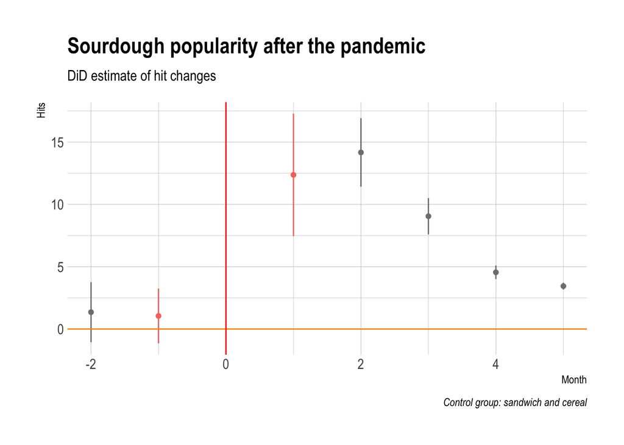

```r
###--- Plot
m4_tbl <-
  tidy(m4) |>
  mutate(month = as.integer(str_extract(term, "-?\\d+")),
         t = ifelse(month %in% c(-1,1), TRUE, as.character(NA))) |>
  clean_names() |>
  select(month,estimate, std_error, t)



m4_tbl |>
  mutate(conf_low = estimate - 1.96*std_error,
         conf_high = estimate + 1.96*std_error) |>
  ggplot(aes(month,estimate, color = t)) +
  geom_point() +
  geom_linerange(aes(ymin = conf_low, ymax = conf_high)) +
  geom_hline(aes(yintercept = 0), color = "orange2") +
  geom_vline(aes(xintercept = 0), color = "red") +
    labs(title = "Sourdough popularity after the pandemic",
         subtitle = "DiD estimate of hit changes",
         x = "Month",
         y = "Hits",
         caption = "Control group: sandwich and cereal") +
  theme(legend.position = "none")
```

**The figure shows a strong effect of the pandemic on the hits on sourdough. The change in sourdough hits during the first and second months of the pandemic was larger than changes in hits for the control group. The effect fades over time, getting closer to 0. The fact that the effects 1 and 2 months before the pandemic are so close to 0 reassures that the prior trends are similar for treatment and controls.**